# PhenoRec Tutorial: Phenotype-Preserving Integration of scATAC-seq Data

In this tutorial, we demonstrate how to use **PhenoRec** for phenotype-preserving integration of single-cell chromatin accessibility (scATAC-seq) data.

Here, we use a type 2 diabetes (**T2D**) snATAC-seq dataset from GEO accession **GSE169453**. The dataset was generated from human pancreatic islet samples profiled using the 10x Genomics Chromium Single Cell ATAC platform and includes nondiabetic and T2D donors. For this tutorial, we randomly subsampled 100,000 cells for illustration purposes.

The tutorial consists of four main stages:

1. Preprocess the scATAC-seq data.
2. Estimate latent cell states.
3. Apply PhenoRec to recover phenotype-associated signals.
4. Visualize the phenotype-preserving integrated data.

# 1 Load required packages

We first load PhenoRec together with the packages required for this tutorial.

```r
library(PhenoRec)
library(Matrix)
library(data.table)
library(Signac)
library(Seurat)
```

# 2 Load data

We load the chromatin accessibility matrix and cell-level metadata.

```r
atac_count <- readRDS("T2D_data.RDS")
metadata <- readRDS("T2D_metadata.RDS")

head(metadata)
```

```
##                         orig.ident nCount_ATAC nFeature_ATAC
## JYH792_AAACGAAAGCATTGGG     JYH792        2724          1415
## JYH792_AAACGAACATGCTATG     JYH792        5406          2671
## JYH792_AAACGAAGTTCCCAAA     JYH792        5711          2878
## JYH792_AAACGAAGTTCTGAAC     JYH792        2166          1111
## JYH792_AAACGAATCGCGCCAA     JYH792        3607          1825
## JYH792_AAACTCGAGAAGCCGT     JYH792        6599          3200
##                                           index  donor duplicated_reads
## JYH792_AAACGAAAGCATTGGG JYH792_AAACGAAAGCATTGGG JYH792             1805
## JYH792_AAACGAACATGCTATG JYH792_AAACGAACATGCTATG JYH792            15340
## JYH792_AAACGAAGTTCCCAAA JYH792_AAACGAAGTTCCCAAA JYH792             2779
## JYH792_AAACGAAGTTCTGAAC JYH792_AAACGAAGTTCTGAAC JYH792             2869
## JYH792_AAACGAATCGCGCCAA JYH792_AAACGAATCGCGCCAA JYH792             4122
## JYH792_AAACTCGAGAAGCCGT JYH792_AAACTCGAGAAGCCGT JYH792             3962
##                         frac_duplicated_reads frac_mito_reads
## JYH792_AAACGAAAGCATTGGG            0.11178547    0.0066071554
## JYH792_AAACGAACATGCTATG            0.31711250    0.0254839201
## JYH792_AAACGAAGTTCCCAAA            0.09677869    0.0031811305
## JYH792_AAACGAAGTTCTGAAC            0.13725959    0.0007241936
## JYH792_AAACGAATCGCGCCAA            0.12623649    0.0016589016
## JYH792_AAACTCGAGAAGCCGT            0.12267773    0.0006385470
##                         frac_promoters_used frac_reads_in_peaks
## JYH792_AAACGAAAGCATTGGG          0.09164685           0.4976297
## JYH792_AAACGAACATGCTATG          0.14659361           0.5005787
## JYH792_AAACGAAGTTCCCAAA          0.14075261           0.5316599
## JYH792_AAACGAAGTTCTGAAC          0.06094283           0.3372171
## JYH792_AAACGAATCGCGCCAA          0.08994107           0.3662719
## JYH792_AAACTCGAGAAGCCGT          0.15140081           0.5511696
##                         frac_reads_in_promoters log10_n_counts log10_n_peaks
## JYH792_AAACGAAAGCATTGGG               0.2753131       4.158000      3.832892
## JYH792_AAACGAACATGCTATG               0.2057931       4.514070      4.156186
## JYH792_AAACGAAGTTCCCAAA               0.2499319       4.416324      4.070370
## JYH792_AAACGAAGTTCTGAAC               0.1442747       4.261239      3.910464
## JYH792_AAACGAATCGCGCCAA               0.1387661       4.460492      4.102811
## JYH792_AAACTCGAGAAGCCGT               0.2537716       4.459875      4.083753
##                         n_counts n_peaks reads_in_peaks reads_in_promoters
## JYH792_AAACGAAAGCATTGGG    14388    6806           7033               3891
## JYH792_AAACGAACATGCTATG    32664   14328          16003               6579
## JYH792_AAACGAAGTTCCCAAA    26081   11759          13661               6422
## JYH792_AAACGAAGTTCTGAAC    18249    8137           6049               2588
```

[output cut: 8 more lines]

```
## JYH792_AAACTCGAGAAGCCGT                 32296     2929                18
##                         unique_usable_reads leiden n_count_500bp n_peak_500bp
## JYH792_AAACGAAAGCATTGGG               14133      4          7277         3541
## JYH792_AAACGAACATGCTATG               31969      7         17941         8347
## JYH792_AAACGAAGTTCCCAAA               25695      1         14042         6538
## JYH792_AAACGAAGTTCTGAAC               17938      1          6345         3137
## JYH792_AAACGAATCGCGCCAA               28285      0         11092         5345
## JYH792_AAACTCGAGAAGCCGT               28171      0         16057         7202
##                         Diabetes.status cell_type
## JYH792_AAACGAAAGCATTGGG    Non-diabetic     Alpha
## JYH792_AAACGAACATGCTATG    Non-diabetic    Acinar
## JYH792_AAACGAAGTTCCCAAA    Non-diabetic      Beta
## JYH792_AAACGAAGTTCTGAAC    Non-diabetic      Beta
## JYH792_AAACGAATCGCGCCAA    Non-diabetic     Alpha
## JYH792_AAACTCGAGAAGCCGT    Non-diabetic     Alpha
```

The accessibility matrix contains genomic regions as rows and cells as columns. The metadata contain sample/batch identity (`donor`), phenotype information (`Diabetes.status`), and cell-type annotations (`cell_type`).

We construct a Signac chromatin assay from the accessibility matrix and then create a Seurat object.

```r
seurat_data <- CreateChromatinAssay(
  counts = atac_count,
  sep = c("-", "-")
)

seurat_data <- CreateSeuratObject(
  counts = seurat_data,
  assay = "ATAC",
  meta.data = metadata
)
```

# 3 Preprocess the scATAC-seq data

For scATAC-seq data, we use the TF-IDF and latent semantic indexing (LSI) workflow implemented in Signac. If you are unfamiliar with this workflow, please refer to the official [tutorial](https://stuartlab.org/signac/articles/pbmc_vignette).

```r
seurat_data <- RunTFIDF(seurat_data)
```

```
## Performing TF-IDF normalization
```

```r
seurat_data <- RunSVD(
  seurat_data,
  n = 150,
  features = rownames(seurat_data)
)
```

```
## Running SVD
```

```
## Scaling cell embeddings
```

The first LSI component in scATAC-seq data is often strongly associated with sequencing depth. We therefore examine the correlation between LSI dimensions and ATAC sequencing depth.

```r
DepthCor(
  seurat_data,
  assay = "ATAC",
  reduction = "lsi",
  n = 60
)
```

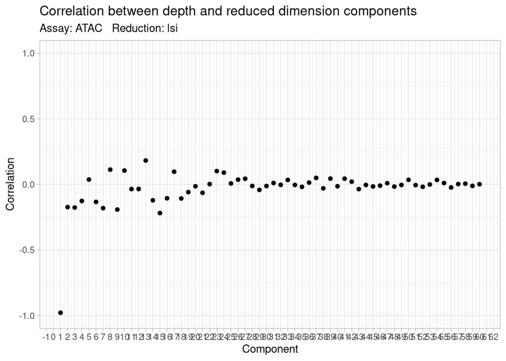

In this example, the first LSI dimension shows a strong association with sequencing depth.

We construct a UMAP representation using LSI dimensions 2–50.

```r
seurat_data <- RunUMAP(
  object = seurat_data,
  reduction = "lsi",
  dims = 2:50
)
```

The UMAP embedding can be colored by cell type, sample, and phenotype.

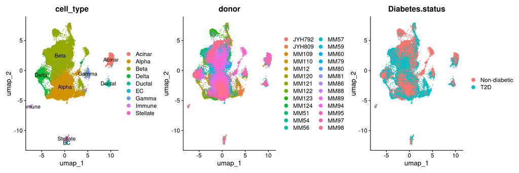

```r
DimPlot(
  seurat_data,
  group.by = "cell_type",
  label = TRUE
) +
  DimPlot(
    seurat_data,
    group.by = "donor"
  ) +
  DimPlot(
    seurat_data,
    group.by = "Diabetes.status"
  )
```

# 4 Estimate latent cell states

PhenoRec first requires an estimate of the underlying cell-state representation, denoted by (Z) in the PhenoRec model. In the current workflow, conventional integration with Harmony is used to obtain this representation.

Harmony is applied to LSI dimensions 2–150 using `donor` as the batch variable. The first LSI dimension is excluded because of its strong association with sequencing depth.

```r
harmony_z <- harmony::RunHarmony(
  seurat_data@reductions$lsi@cell.embeddings[, 2:150],
  seurat_data@meta.data,
  "donor"
)
```

```
## Transposing data matrix
```

```
## Initializing state using k-means centroids initialization
```

```
## Harmony 1/10
```

```
## Harmony 2/10
```

```
## Harmony converged after 2 iterations
```

We store this representation in the Seurat object under the reduction name `estimate_z`.

```r
seurat_data[["estimate_z"]] <- CreateDimReducObject(
  embeddings = harmony_z,
  key = "estimatez_"
)
```

The reduction name `estimate_z` is required by the current implementation of PhenoRec, which retrieves the estimated latent cell states from this reduction.

# 5 Encode batch and phenotype information

PhenoRec requires encoded matrices of categorical batch and phenotype variables. These are generated using `encoding_function()`.

```r
encoding_data <- encoding_function(
  seurat_data = seurat_data,
  batch_id = "donor",
  phenotype_id = "Diabetes.status"
)
```

Here, `donor` specifies the sample/batch variable, whereas `Diabetes.status` specifies the biological phenotype of interest.

# 6 Run PhenoRec

We now apply PhenoRec to the scATAC-seq data.

```r
input_data <- list(
  atac_data = seurat_data,
  encoding_data = encoding_data
)
```

```r
PhenoRec_result <- PhenoRec_ATAC(
  input = input_data,
  ncores = 30
)
```

`ncores` specifies the number of parallel worker used during feature-wise Bernoulli model fitting. Choose this value according to the computational resources available on your system.

The principal output for downstream analysis is:

```r
integrated_data <- PhenoRec_result$integrated_data
```

`integrated_data` contains the PhenoRec-recovered chromatin accessibility data, with cells represented by rows and genomic regions by columns. This integrated data removes unwanted batch variation while preserving biologically meaningful phenotype-associated variation.

# 7 Visualize the PhenoRec-recovered data

We create a new Seurat object containing the PhenoRec-recovered chromatin accessibility data.

```r
integrated_assay <- CreateAssayObject(
  data = t(integrated_data)
)

integrated_obj <- CreateSeuratObject(
  counts = integrated_assay,
  assay = "ATAC",
  meta.data = seurat_data@meta.data
)
```

We scale the recovered accessibility values and compute PCA and UMAP.

```r
integrated_obj <- ScaleData(integrated_obj)
integrated_obj <- RunPCA(
  integrated_obj,
  features = rownames(integrated_obj)
)
```

[output not shown]

[output cut: 12 more lines]

```r
integrated_obj <- RunUMAP(
  integrated_obj,
  dims = 1:50
)
```

We visualize the UMAP by cell type, sample, and phenotype.

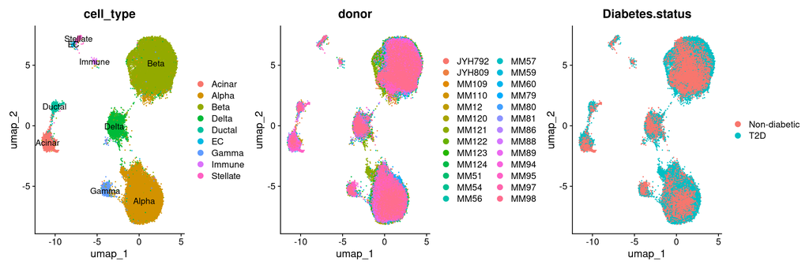

```r
DimPlot(
  integrated_obj,
  group.by = "cell_type",
  label = TRUE
) +
  DimPlot(
    integrated_obj,
    group.by = "donor"
  ) +
  DimPlot(
    integrated_obj,
    group.by = "Diabetes.status"
  )
```

This integrated representation preserves biologically meaningful phenotype signals and can be used to identify cell populations exhibiting pronounced state changes across phenotypes.